# parietal_occipital_analysis

## Data wrangling

#### Packages

```r
library(tidyverse)
library(ggpubr)
library(rstatix)
library(broom)
library(readxl)
```

#### Uploading the necessary data

```r
slope <-
  read_xlsx("slope_off_ch_groups.xlsx", sheet = "slope_each_ch_sbj")

iaf <-read_xlsx("iaf_power_ch_groups.xlsx", sheet = "iaf_each_ch_sbj_removed_subj" )

power <-read_xlsx("iaf_power_ch_groups.xlsx", sheet = "power_each_ch_sbj_removed_subj" )

demographic <-read_xlsx("id_age.xlsx")
```

#### Selecting electrodes

```r
slope <- slope |> select(id, group,Pz, P1, P2, PO3, POz, PO4, O1, Oz, O2)
iaf <- iaf|> select(id, group, Pz, P1, P2, PO3, POz, PO4, O1, Oz, O2)
power <- power |> select(id, group, Pz, P1, P2, PO3, POz, PO4, O1, Oz, O2)
```

#### Removing subjects

```r
#remove subjects

# List of IDs to remove
ids_to_remove <- c(236, 32, 107, 113, 221, 13, 118, 122)

# Remove rows for the specified IDs in each dataset
slope <- slope[!(slope$id %in% ids_to_remove) & !(slope$group == "M"), ]
iaf <- iaf[!(iaf$id %in% ids_to_remove) & !(iaf$group == "M"), ]
power <- power[!(power$id %in% ids_to_remove) & !(power$group == "M"), ]

# Check if all datasets have equal number of rows
num_rows <- nrow(slope)
if (nrow(iaf) != num_rows || nrow(power) != num_rows) {
  print("Warning: Datasets do not have an equal number of rows.")
}
```

#### Calculating the average (mean) of occipital-parietal electrodes

```r
slope <- slope |> rowwise() |>
  mutate(Occ_pariet = mean(c_across(Pz:O2), na.rm = TRUE))

iaf <- iaf |> rowwise() |>
  mutate(Occ_pariet = mean(c_across(Pz:O2), na.rm = TRUE))

power <- power |> rowwise() |>
  mutate(Occ_pariet = mean(c_across(Pz:O2), na.rm = TRUE))
```

#### Combing demographic data

```r
slope <- merge(slope, demographic, by = "id", all.x = TRUE)
iaf <- merge(iaf, demographic, by = "id", all.x = TRUE)
power <- merge(power, demographic, by = "id", all.x = TRUE)
```

#### Group order

```r
slope <- slope |> mutate(group = factor(group, levels = c("NCF", "NCL", "OC", "IUD")))
iaf <- iaf|> mutate(group = factor(group, levels = c("NCF", "NCL", "OC", "IUD")))
power <- power |>  mutate(group = factor(group, levels = c("NCF", "NCL", "OC", "IUD")))
```

## Data analysis

### 1. Assumption testing

**a. Quick visualization and outlines detection**

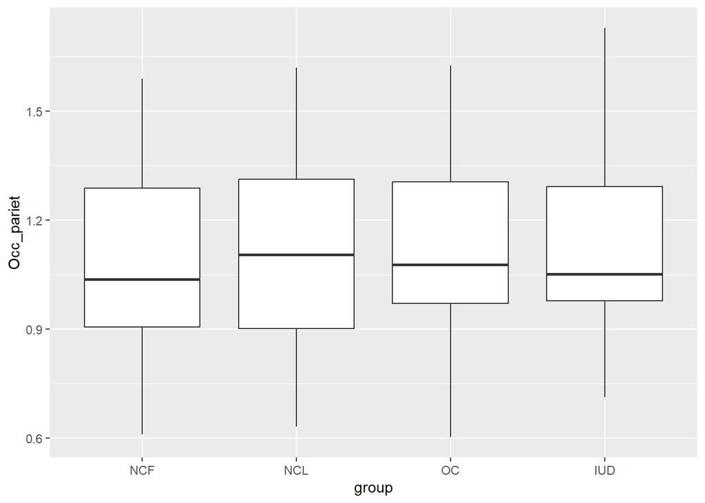

```r
ggplot(slope, aes(group, Occ_pariet))+
  geom_boxplot()
```

```r
slope |>
  group_by(group) |>
  identify_outliers(Occ_pariet)
```

```
 [1] group        id           Pz           P1           P2
 [6] PO3          POz          PO4          O1           Oz
[11] O2           Occ_pariet   age          Estradiol    Progesterone
[16] Testosterone BMI          is.outlier   is.extreme
<0 rows> (or 0-length row.names)
```

No outliers in variable

**b. Linearity assumption**

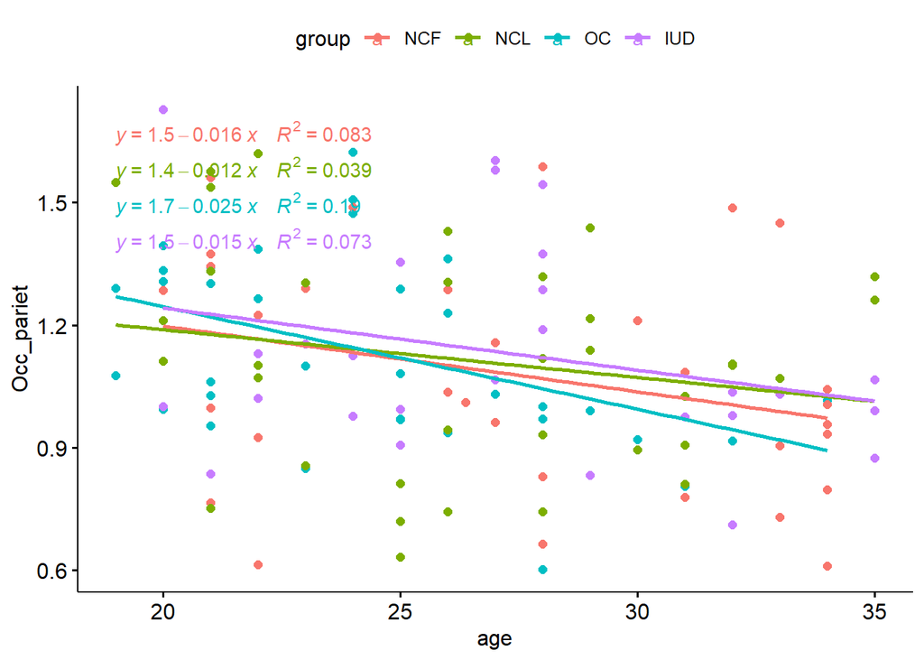

```r
ggscatter(
  slope, x = "age", y = "Occ_pariet",
  color = "group", add = "reg.line"
  ) +
  stat_regline_equation(
    aes(label =  paste(..eq.label.., ..rr.label.., sep = "~~~~"), color = group)
    )
```

**c. Homogeneity of regression slopes**

```r
slope |>  anova_test(Occ_pariet ~ group*age)
```

```
ANOVA Table (type II tests)

     Effect DFn DFd      F     p p<.05   ges
1     group   3 123  0.242 0.867       0.006
2       age   1 123 11.325 0.001     * 0.084
3 group:age   3 123  0.301 0.824       0.007
```

There is no significant interaction between age and group

**d. Normality testing (residuals)**

```r
model_slope <- lm(Occ_pariet ~ group + age, data = slope)
```

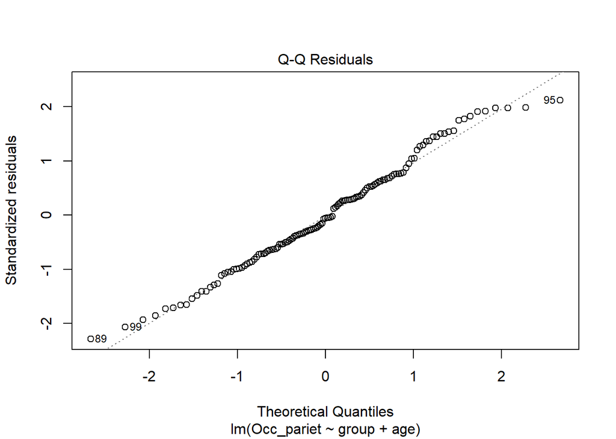

```r
plot(model_slope,2)
```

```r
shapiro_test(residuals(model_slope))
```

```
# A tibble: 1 × 3
  variable               statistic p.value
  <chr>                      <dbl>   <dbl>
1 residuals(model_slope)     0.987   0.225
```

The data is normally distributed

**d. Homogeneity of variance**

```r
slope |> levene_test(Occ_pariet ~ group)
```

```
# A tibble: 1 × 4
    df1   df2 statistic     p
  <int> <int>     <dbl> <dbl>
1     3   127     0.566 0.638
```

Variance is equall in the groups.

### 2. Running ANOVA

```r
slope_aov <- slope |> anova_test(Occ_pariet ~ group + age)

slope_aov
```

```
ANOVA Table (type II tests)

  Effect DFn DFd      F        p p<.05   ges
1  group   3 126  0.247 0.864000       0.006
2    age   1 126 11.516 0.000923     * 0.084
```

No significant difference between groups

### 3. Vizualization

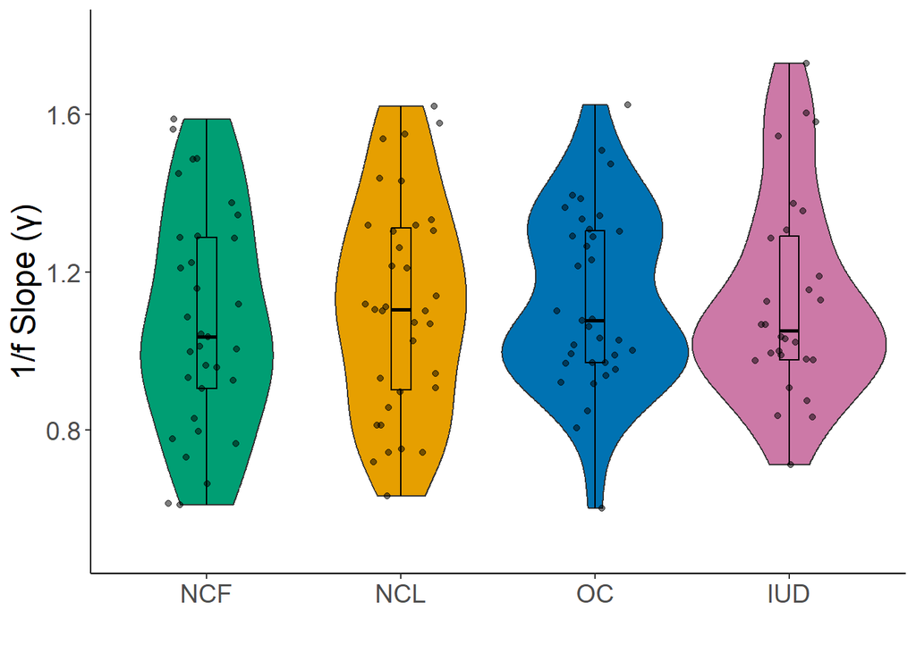

```r
slopeOcc_pr <- ggplot(slope,aes(x = group, y = Occ_pariet, fill = group)) +
  geom_violin(width = 1) +
  geom_boxplot(width = 0.1, color = "black", alpha = 0.2) +
  geom_jitter(width = 0.2, height = 0, alpha = 0.5, color = "black") +
  labs(x = " ") +
  ylab("1/f Slope (γ)") +
  scale_fill_manual(values = c("#009E73","#E69F00", "#0072B2", "#CC79A7"))+
  theme_classic() +
  theme(axis.text = element_text(size = 14), legend.position = "none") +
  font("axis.title", size = 18)+
  ylim(c(0.5, 1.8))
slopeOcc_pr
```

### 1. Assumption testing

**a. Quick visualization and outlines detection**

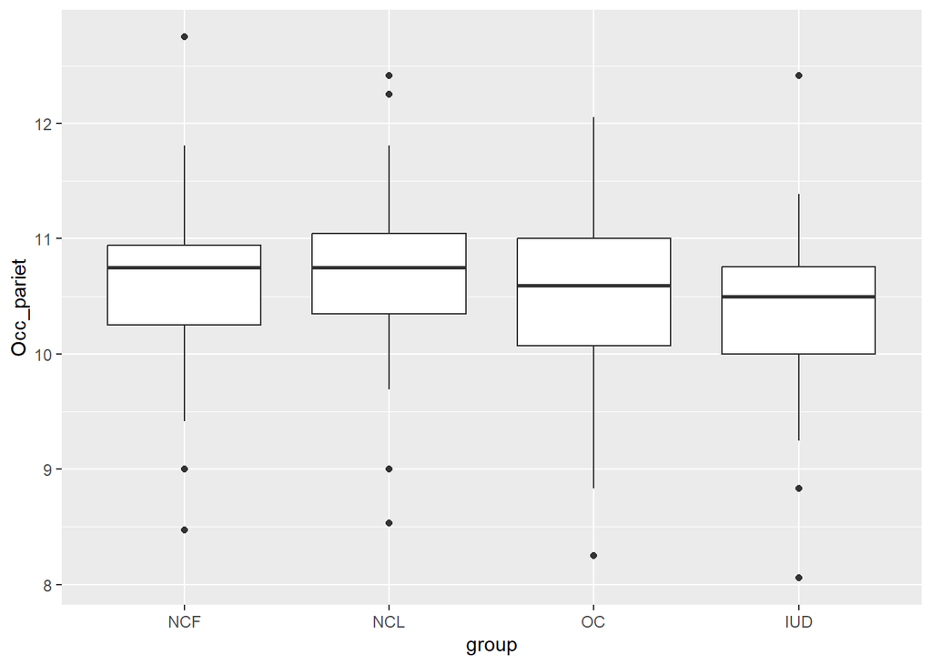

```r
ggplot(iaf, aes(group, Occ_pariet))+
  geom_boxplot()
```

```r
iaf |>
  group_by(group) |>
  identify_outliers(Occ_pariet) |>
  select(is.extreme)
```

```
# A tibble: 11 × 1
   is.extreme
   <lgl>
 1 FALSE
 2 FALSE
 3 FALSE
 4 FALSE
 5 FALSE
 6 FALSE
 7 FALSE
 8 FALSE
 9 FALSE
10 FALSE
11 FALSE
```

No extreme outliers

**b. Linearity assumption**

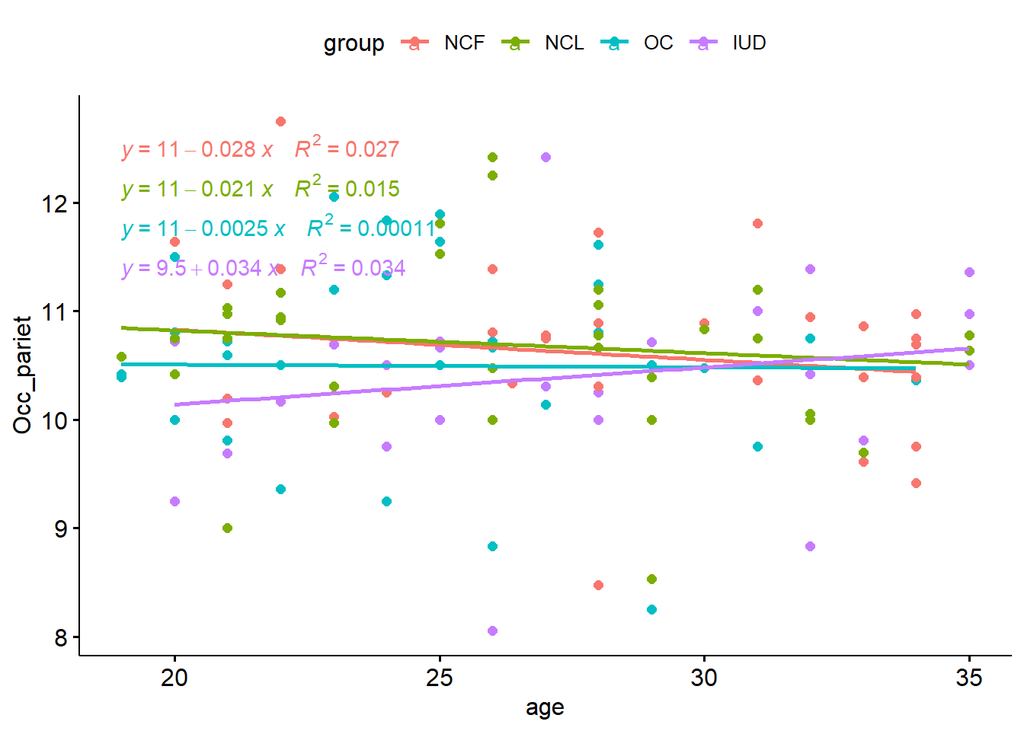

```r
ggscatter(
  iaf, x = "age", y = "Occ_pariet",
  color = "group", add = "reg.line"
  ) +
  stat_regline_equation(
    aes(label =  paste(..eq.label.., ..rr.label.., sep = "~~~~"), color = group)
    )
```

**c. Homogeneity of regression slopes**

```r
iaf %>% anova_test(Occ_pariet ~ group*age)
```

```
ANOVA Table (type II tests)

     Effect DFn DFd     F     p p<.05   ges
1     group   3 123 0.782 0.506       0.019
2       age   1 123 0.191 0.663       0.002
3 group:age   3 123 0.662 0.577       0.016
```

There is no significant interaction between age and group. And no relationship between age and iaf, therefore we can run simpe ANOVA

**d. Normality testing (residuals)**

```r
model_iaf <- lm(Occ_pariet ~ group, data = iaf)
```

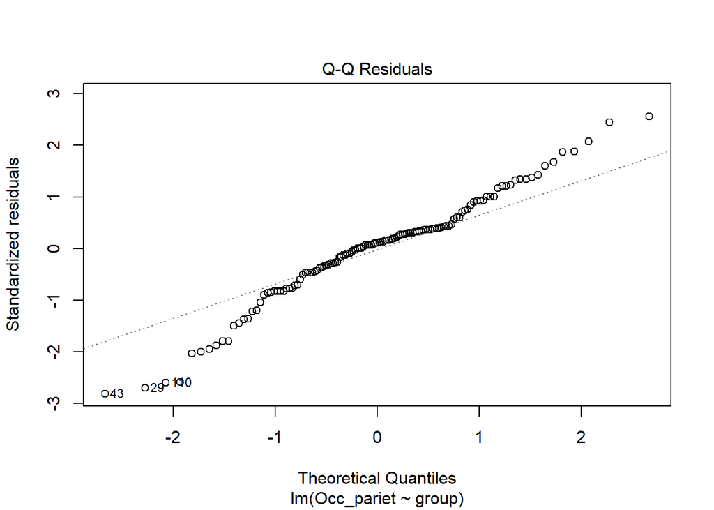

```r
plot(model_iaf,2)
```

```r
shapiro_test(residuals(model_iaf))
```

```
# A tibble: 1 × 3
  variable             statistic p.value
  <chr>                    <dbl>   <dbl>
1 residuals(model_iaf)     0.971 0.00704
```

```r
iaf |>
  group_by(group) |>
  shapiro_test(Occ_pariet)
```

```
# A tibble: 4 × 4
  group variable   statistic     p
  <fct> <chr>          <dbl> <dbl>
1 NCF   Occ_pariet     0.972 0.550
2 NCL   Occ_pariet     0.958 0.193
3 OC    Occ_pariet     0.957 0.191
4 IUD   Occ_pariet     0.954 0.249
```

**d. Homogeneity of variance**

```r
iaf |> levene_test(Occ_pariet ~ group)
```

```
# A tibble: 1 × 4
    df1   df2 statistic     p
  <int> <int>     <dbl> <dbl>
1     3   127     0.321 0.810
```

Variance is equall in the groups.

### 2. Running ANOVA

```r
iaf_aov <- iaf |> anova_test(Occ_pariet ~ group)

iaf_aov
```

```
ANOVA Table (type II tests)

  Effect DFn DFd     F     p p<.05   ges
1  group   3 127 0.777 0.509       0.018
```

No significant difference between groups

### 3. Vizualization

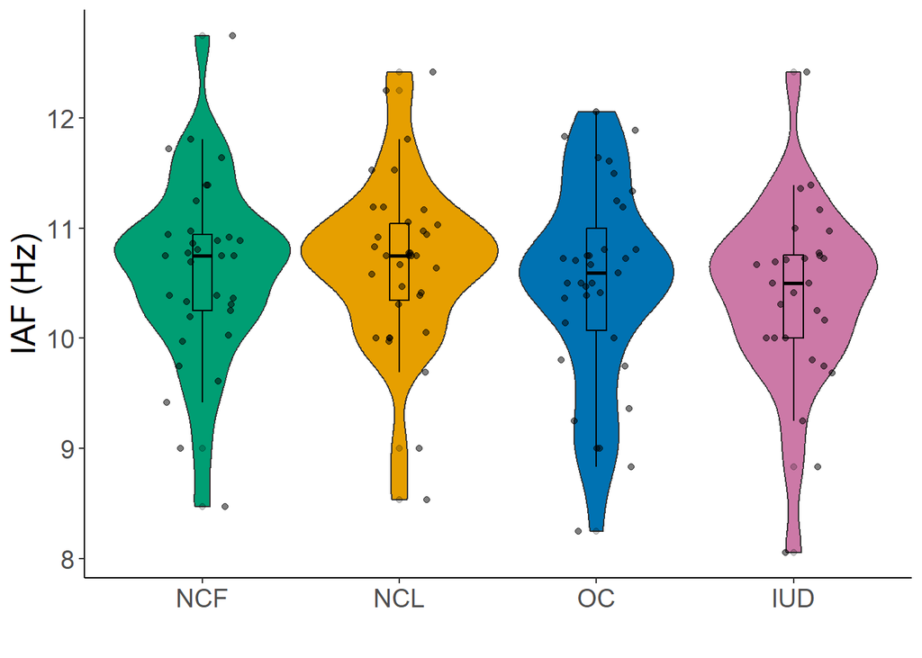

```r
iaf_Occ_pr <- ggplot(iaf,aes(x = group, y = Occ_pariet, fill = group)) +
  geom_violin(width = 1) +
  geom_boxplot(width = 0.1, color = "black", alpha = 0.2) +
  geom_jitter(width = 0.2, height = 0, alpha = 0.5, color = "black") +
  labs(x = " ") +
  ylab("IAF (Hz)") +
  scale_fill_manual(values = c("#009E73","#E69F00", "#0072B2", "#CC79A7"))+
  theme_classic() +
  theme(axis.text = element_text(size = 14), legend.position = "none") +
  font("axis.title", size = 18)
iaf_Occ_pr
```

### Alpa Power

```r
power$power_log <- log(power$Occ_pariet)
```

### 1. Assumption testing

**a. Quick visualization and outlines detection**

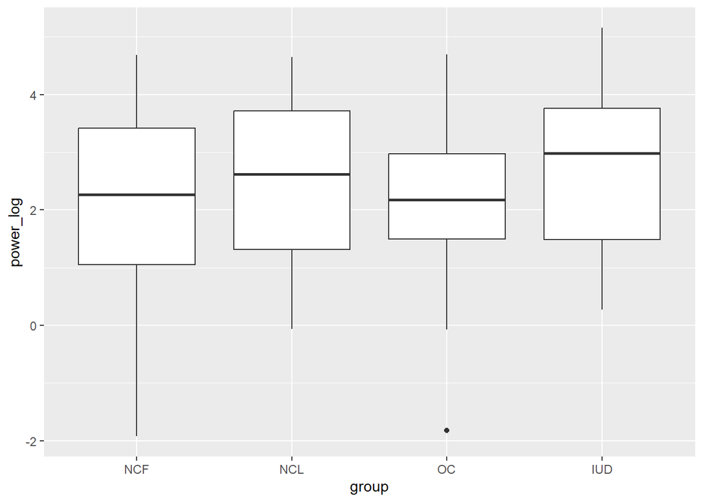

```r
ggplot(power, aes(group, power_log))+
  geom_boxplot()
```

```r
power |>
  group_by(group) |>
  identify_outliers(power_log) |>
  select(is.extreme)
```

```
# A tibble: 1 × 1
  is.extreme
  <lgl>
1 FALSE
```

**b. Linearity assumption**

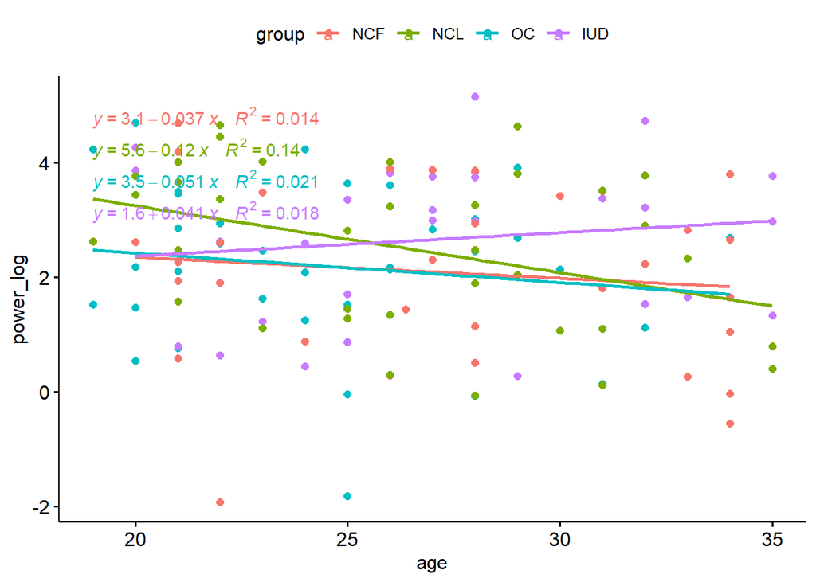

```r
ggscatter(
  power, x = "age", y = "power_log",
  color = "group", add = "reg.line"
  ) +
  stat_regline_equation(
    aes(label =  paste(..eq.label.., ..rr.label.., sep = "~~~~"), color = group)
    )
```

**c. Homogeneity of regression slopes**

```r
power %>% anova_test(power_log ~ group*age)
```

```
ANOVA Table (type II tests)

     Effect DFn DFd     F     p p<.05   ges
1     group   3 123 1.344 0.263       0.032
2       age   1 123 2.592 0.110       0.021
3 group:age   3 123 1.298 0.278       0.031
```

There is no significant interaction between age and group

**d. Normality testing (residuals)**

```r
model_power <- lm(power_log ~ group, data = power)
```

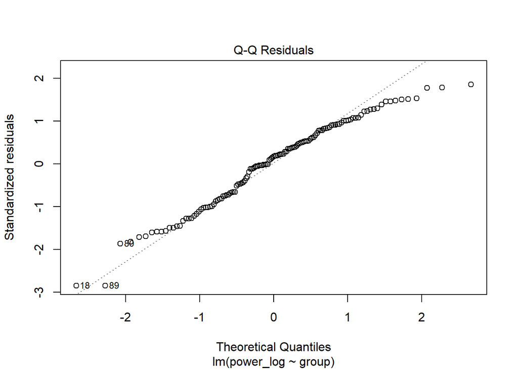

```r
plot(model_power,2)
```

```r
shapiro_test(residuals(model_power))
```

```
# A tibble: 1 × 3
  variable               statistic p.value
  <chr>                      <dbl>   <dbl>
1 residuals(model_power)     0.974  0.0131
```

```r
power |>
  group_by(group) |>
  shapiro_test(power_log)
```

```
# A tibble: 4 × 4
  group variable  statistic     p
  <fct> <chr>         <dbl> <dbl>
1 NCF   power_log     0.973 0.559
2 NCL   power_log     0.948 0.101
3 OC    power_log     0.970 0.439
4 IUD   power_log     0.942 0.126
```

**d. Homogeneity of variance**

```r
power |> levene_test(power_log ~ group)
```

```
# A tibble: 1 × 4
    df1   df2 statistic     p
  <int> <int>     <dbl> <dbl>
1     3   127     0.210 0.889
```

Variance is equall in the groups.

### 2. Running ANOVA

```r
power_aov <- power |> anova_test(power_log ~ group + age)

power_aov
```

```
ANOVA Table (type II tests)

  Effect DFn DFd     F     p p<.05   ges
1  group   3 126 1.334 0.266       0.031
2    age   1 126 2.574 0.111       0.020
```

No significant difference between groups

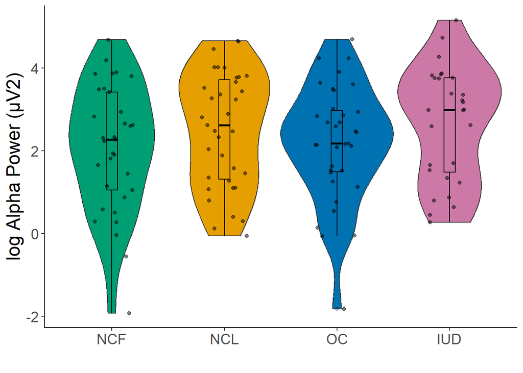

```r
power_graphic <- ggplot(power, aes(x = group, y = power_log, fill = group)) +
  geom_violin(width = 1) +
  geom_boxplot(width = 0.1, color = "black", alpha = 0.2) +
  geom_jitter(width = 0.2, height = 0, alpha = 0.5, color = "black") +
  labs(x = "") +
  ylab("log Alpha Power (µV2)") +
  scale_fill_manual(values = c("#009E73","#E69F00", "#0072B2", "#CC79A7"))+
  theme_classic() +
  theme(axis.text = element_text(size = 14), legend.position = "none") +
  font("axis.title", size = 18)
power_graphic
```

```r
library(patchwork)
```

```r
graphics <- slopeOcc_pr /
iaf_Occ_pr /
power_graphic
```

```r
ggsave("graphics.png", width = 6, height = 8)
```